# Exploratory Data Analysis (adding visualization to the chain)

Hector Corrada Bravo  
CADi 2015

### Visual EDA

- Our goal in EDA is to apply transformations, compute summarizations and visualizations to explore general trends in datasets.
- We have seen some basic examples of statistics we would like to compute and important univariate plots. Let's get a little more complicated.
- Before we do that, let's step back and formalize some of what we are doing in visual EDA

### ggplot2

We will build our intuition using the *grammar of graphics* as implemented in `ggplot2`. The central premise is to characterize the building pieces behind plots:

1. The data that goes into a plot, works best when data is tidy
2. The mapping between data and *aesthetic* attributes
3. The *geometric* representation of these attributes

### Simple example

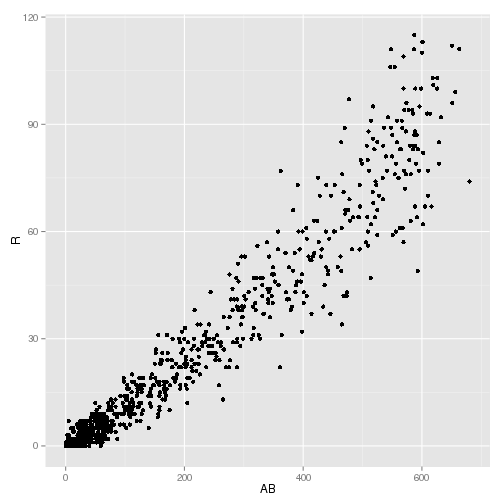

```r
library(dplyr)
library(ggplot2)
library(Lahman)
batting <- tbl_df(Batting)

# scatter plot of at bats vs. runs for 2010
batting %>%
  filter(yearID == "2010") %>%
  ggplot(aes(x=AB, y=R)) +
    geom_point()
```

### Simple example

```r
# scatter plot of at bats vs. runs for 2010
batting %>%
  filter(yearID == "2010") %>%
  ggplot(aes(x=AB, y=R)) +
    geom_point()
```

**Data**: Batting table filtering for year  
**Aesthetic attributes**:

- x-axis mapped to variables `AB`
- y-axis mapped to variable `R`

**Geometric Representation**: points!

### Simple example

Now, you can cleanly distinguish the constituent parts of the plot. E.g., change the geometric representation

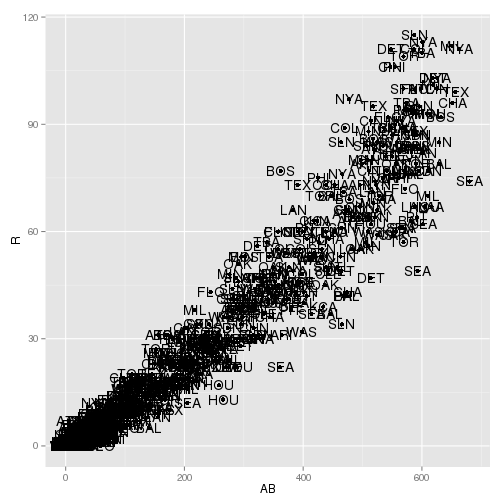

```r
# scatter plot of at bats vs. runs for 2010
batting %>%
  filter(yearID == "2010") %>%
  ggplot(aes(x=AB, y=R, label=teamID)) +
    geom_text() +
    geom_point()
```

### Simple example

Now, you can cleanly distinguish the constituent parts of the plot. E.g., change the data.

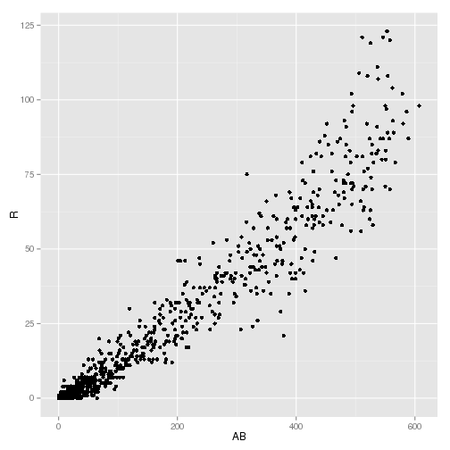

```r
# scatter plot of at bats vs. runs for 1995
batting %>%
  filter(yearID == "1995") %>%
  ggplot(aes(x=AB, y=R)) +
    geom_point()
```

### Simple example

Now, you can cleanly distinguish the constituent parts of the plot. E.g., change the aesthetic.

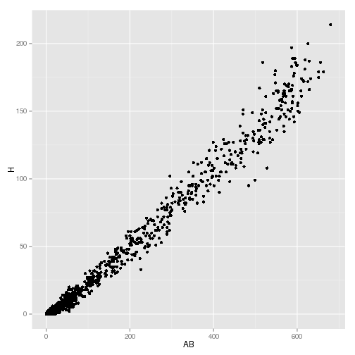

```r
# scatter plot of at bats vs. hits for 2010
batting %>%
  filter(yearID == "2010") %>%
  ggplot(aes(x=AB, y=H)) +
    geom_point()
```

### Line Plot

Let's make a line plot (pg. 52)

What do we change? (data, aesthetic or geometry?)

```r
batting %>%
  filter(yearID == "2010") %>%
  sample_n(100) %>%
  ggplot(aes(x=AB, y=H)) +
  geom_line()
```

[output not shown]

### Summarizing trend

Let's add a regression line (pg. 54)

What do we add? (data, aesthetic or geometry?)

```r
batting %>%
  filter(yearID == "2010") %>%
  ggplot(aes(x=AB, y=H)) +
  geom_point() +
  geom_smooth(method=lm)
```

[output not shown]

### Other aesthetics

- Color: color by categorical variable

```r
batting %>%
  filter(yearID == "2010") %>%
  ggplot(aes(x=AB, y=H, color=lgID)) +
  geom_point() +
  geom_smooth(method=lm)
```

[output not shown]

### Other aesthetics

```r
batting %>%
  filter(yearID == "2010") %>%
  ggplot(aes(x=AB, y=R, size=HR)) +
  geom_point() +
  geom_smooth(method=lm)
```

[output not shown]

### Faceting

The last major component of exploratory analysis called `faceting` in visualization, corresponds to `conditioning` in modeling, we've seen it as the motivation of `grouping` when arranging data.

```r
batting %>%
  filter(yearID %in% c("1995", "2000", "2010")) %>%
  ggplot(aes(x=AB, y=R, size=HR)) +
  facet_grid(lgID~yearID) +
  geom_point() +
  geom_smooth(method=lm)
```

[output not shown]

### Faceting

The last major component of exploratory analysis called `faceting` in visualization, corresponds to `conditioning` in modeling, we've seen it as the motivation of `grouping` when arranging data.

```r
batting %>%
  filter(yearID %in% c("1995", "2000", "2010")) %>%
  ggplot(aes(x=AB, y=R, size=HR)) +
  facet_grid(lgID~yearID) +
  geom_point() +
  geom_smooth(method=lm)
```

[output not shown]

### Summary

Exploratory analysis:

- Think of statistics that summarize data well (we've seen the five number summary)
- Interpret these statistics relative to other data (analytical or empirical, the q-q plot)
- Data transformations should be interpreted this way as well
- When visually exploring, think of data/aesthetic/geometry separately to organize your exploration.